# Intro to R

**CCDL 2020**

## Objective for this notebook analysis:

We’ve performed differential expression analyses on a pre-processed [astrocytoma microarray dataset](https://www.refine.bio/experiments/GSE44971/gene-expression-data-from-pilocytic-astrocytoma-tumour-samples-and-normal-cerebellum-controls). We performed three sets of contrasts:

1. `sex` category contrasting: Male vs Female
2. `tissue` category contrasting : Pilocytic astrocytoma tumor samples vs normal cerebellum samples
3. An interaction of both `sex` and `tissue`.

*Resources for learning R*

- [Swirl, an interactive tutorial](https://swirlstats.com/)
- [R Markdown](http://rmarkdown.rstudio.com)
- [R for Data Science](https://r4ds.had.co.nz/)
- [Tutorial on R, RStudio and R Markdown](https://ismayc.github.io/rbasics-book/)
- [Handy R cheatsheets](https://www.rstudio.com/resources/cheatsheets/)
- [R Notebooks tutorial](https://bookdown.org/yihui/rmarkdown/)

## Set Up

We saved these results to a tab separated values (TSV) file called `gene_results_GSE44971.tsv`. Its been saved to the `data` folder.  
File paths are relative to where this notebook file (.Rmd) is saved. We saved our results file to a folder called `data`. So we can reference it later, let’s make a object in our environment with our data directory name.

```r
data_dir <- "data"
```

Magrittr pipe

```r
`%>%` <- dplyr::`%>%`
```

Let’s declare our output folder name as its own object.

```r
plots_dir <- "plots"
```

We can also create a directory if it doesn’t already exist.

```r
if(!dir.exists(plots_dir)) {
  dir.create(plots_dir)
}
```

## Read in the differential expression analysis results file

Here we are using a function `read_tsv` from a library of functions called `readr`.

```r
stats_df <- readr::read_tsv(file.path(data_dir,
                                      "gene_results_GSE44971.tsv"))
```

Let’s take a look at what this data.frame looks like:

```r
stats_df
```

| ensembl_id | gene_symbol | contrast | log_fold_change | avg_expression | t_statistic | p_value | adj_p_value |
| --- | --- | --- | --- | --- | --- | --- | --- |
| ENSG00000000003 | TSPAN6 | male_female | -4.076885e+00 | 8.361818346 | -2.524435209 | 1.451222e-02 | 8.819912e-02 |
| ENSG00000000005 | TNMD | male_female | -2.073449e-02 | -0.051863725 | -0.196392942 | 8.450285e-01 | 9.652935e-01 |
| ENSG00000000419 | DPM1 | male_female | 1.161674e+00 | 10.500009306 | 1.127409578 | 2.644773e-01 | 5.827042e-01 |
| ENSG00000000457 | SCYL3 | male_female | 1.020261e-01 | 1.547080662 | 0.646384900 | 5.207257e-01 | 8.095245e-01 |
| ENSG00000000460 | C1orf112 | male_female | -1.255173e-01 | 0.577467578 | -1.000593000 | 3.214176e-01 | 6.461213e-01 |
| ENSG00000000938 | FGR | male_female | 1.740169e-01 | 0.987677977 | 0.512776928 | 6.101664e-01 | 8.651771e-01 |
| ENSG00000000971 | CFH | male_female | 3.131755e-02 | 3.162651700 | 0.023742808 | 9.811439e-01 | 9.967261e-01 |
| ENSG00000001036 | FUCA2 | male_female | 1.351790e-01 | 3.148617334 | 0.297080210 | 7.675275e-01 | 9.383822e-01 |
| ENSG00000001084 | GCLC | male_female | -2.879890e-02 | 2.090725523 | -0.080835608 | 9.358669e-01 | 9.883926e-01 |
| ENSG00000001167 | NFYA | male_female | 3.961795e-03 | 0.662320894 | 0.061903569 | 9.508647e-01 | 9.908180e-01 |

[output cut: 990 more lines]

We can take a look at a column individually by using a `$`.

```r
stats_df$contrast
```

```
   [1] "male_female" "male_female" "male_female" "male_female"
   [5] "male_female" "male_female" "male_female" "male_female"
   [9] "male_female" "male_female" "male_female" "male_female"
  [13] "male_female" "male_female" "male_female" "male_female"
  [17] "male_female" "male_female" "male_female" "male_female"
  [21] "male_female" "male_female" "male_female" "male_female"
  [25] "male_female" "male_female" "male_female" "male_female"
  [29] "male_female" "male_female" "male_female" "male_female"
  [33] "male_female" "male_female" "male_female" "male_female"
  [37] "male_female" "male_female" "male_female" "male_female"
  [41] "male_female" "male_female" "male_female" "male_female"
  [45] "male_female" "male_female" "male_female" "male_female"
  [49] "male_female" "male_female" "male_female" "male_female"
  [53] "male_female" "male_female" "male_female" "male_female"
  [57] "male_female" "male_female" "male_female" "male_female"
```

[output cut: 236 more lines]

If we want to see less values at once, we can use brackets with the indices of the values we’d like returned.

```r
stats_df$avg_expression[1:10]
```

```
 [1]  8.36181835 -0.05186373 10.50000931  1.54708066  0.57746758
 [6]  0.98767798  3.16265170  3.14861733  2.09072552  0.66232089
```

Let’s checkout how many rows of data there are per each contrast.

```r
summary(as.factor(stats_df$contrast))
```

```
astrocytoma_normal        interaction        male_female
             20056              20056              20056
```

## Tidyverse brief intro

Make a new variable of -log10 adjusted p values.

```r
stats_df <- stats_df %>%
  dplyr::mutate(neg_log_p_val = -log10(adj_p_value))
```

Let’s filter to only `male_female` contrast data.

```r
stats_df %>%
  dplyr::filter(contrast == "male_female")
```

| ensembl_id | gene_symbol | contrast | log_fold_change | avg_expression | t_statistic | p_value | adj_p_value | neg_log_p_val |
| --- | --- | --- | --- | --- | --- | --- | --- | --- |
| ENSG00000000003 | TSPAN6 | male_female | -4.076885e+00 | 8.361818346 | -2.524435209 | 1.451222e-02 | 8.819912e-02 | 1.054536e+00 |
| ENSG00000000005 | TNMD | male_female | -2.073449e-02 | -0.051863725 | -0.196392942 | 8.450285e-01 | 9.652935e-01 | 1.534062e-02 |
| ENSG00000000419 | DPM1 | male_female | 1.161674e+00 | 10.500009306 | 1.127409578 | 2.644773e-01 | 5.827042e-01 | 2.345518e-01 |
| ENSG00000000457 | SCYL3 | male_female | 1.020261e-01 | 1.547080662 | 0.646384900 | 5.207257e-01 | 8.095245e-01 | 9.177000e-02 |
| ENSG00000000460 | C1orf112 | male_female | -1.255173e-01 | 0.577467578 | -1.000593000 | 3.214176e-01 | 6.461213e-01 | 1.896860e-01 |
| ENSG00000000938 | FGR | male_female | 1.740169e-01 | 0.987677977 | 0.512776928 | 6.101664e-01 | 8.651771e-01 | 6.289500e-02 |
| ENSG00000000971 | CFH | male_female | 3.131755e-02 | 3.162651700 | 0.023742808 | 9.811439e-01 | 9.967261e-01 | 1.424190e-03 |
| ENSG00000001036 | FUCA2 | male_female | 1.351790e-01 | 3.148617334 | 0.297080210 | 7.675275e-01 | 9.383822e-01 | 2.762022e-02 |
| ENSG00000001084 | GCLC | male_female | -2.879890e-02 | 2.090725523 | -0.080835608 | 9.358669e-01 | 9.883926e-01 | 5.070512e-03 |
| ENSG00000001167 | NFYA | male_female | 3.961795e-03 | 0.662320894 | 0.061903569 | 9.508647e-01 | 9.908180e-01 | 4.006133e-03 |

[output cut: 990 more lines]

## Plotting this data

Let’s make a volcano plot with this data.

First let’s take a look at only the tumor vs normal data.

```r
stats_df %>%
  dplyr::filter(contrast == "astrocytoma_normal")
```

| ensembl_id | gene_symbol | contrast | log_fold_change | avg_expression | t_statistic | p_value | adj_p_value | neg_log_p_val |
| --- | --- | --- | --- | --- | --- | --- | --- | --- |
| ENSG00000000003 | TSPAN6 | astrocytoma_normal | 9.060078e-01 | 8.361818346 | 6.462351e-01 | 5.208220e-01 | 6.250737e-01 | 2.040688e-01 |
| ENSG00000000005 | TNMD | astrocytoma_normal | -3.686625e-03 | -0.051863725 | -4.022392e-02 | 9.680607e-01 | 9.778254e-01 | 9.738680e-03 |
| ENSG00000000419 | DPM1 | astrocytoma_normal | 4.608512e-01 | 10.500009306 | 5.152064e-01 | 6.084791e-01 | 7.019647e-01 | 1.536847e-01 |
| ENSG00000000457 | SCYL3 | astrocytoma_normal | 1.086679e-02 | 1.547080662 | 7.930568e-02 | 9.370781e-01 | 9.565857e-01 | 1.927612e-02 |
| ENSG00000000460 | C1orf112 | astrocytoma_normal | 8.298111e-02 | 0.577467578 | 7.620020e-01 | 4.493232e-01 | 5.582374e-01 | 2.531811e-01 |
| ENSG00000000938 | FGR | astrocytoma_normal | 4.581008e-01 | 0.987677977 | 1.554967e+00 | 1.257057e-01 | 2.039274e-01 | 6.905245e-01 |
| ENSG00000000971 | CFH | astrocytoma_normal | 2.911884e+00 | 3.162651700 | 2.542970e+00 | 1.384286e-02 | 3.311849e-02 | 1.479929e+00 |
| ENSG00000001036 | FUCA2 | astrocytoma_normal | 1.748799e+00 | 3.148617334 | 4.427180e+00 | 4.591329e-05 | 2.683091e-04 | 3.571365e+00 |
| ENSG00000001084 | GCLC | astrocytoma_normal | 3.096999e-01 | 2.090725523 | 1.001361e+00 | 3.210496e-01 | 4.299239e-01 | 3.666084e-01 |
| ENSG00000001167 | NFYA | astrocytoma_normal | 7.169222e-02 | 0.662320894 | 1.290383e+00 | 2.023312e-01 | 2.975482e-01 | 5.264427e-01 |

[output cut: 990 more lines]

We can send this data.frame directly into a `ggplot` function.

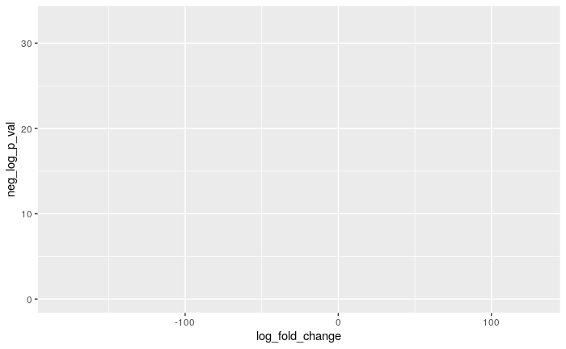

```r
stats_df %>%
  dplyr::filter(contrast == "astrocytoma_normal") %>%
ggplot2::ggplot(ggplot2::aes(x = log_fold_change,
                             y = neg_log_p_val))
```

You’ll notice this plot doesn’t have anything on it because we haven’t specified a plot type yet. To do that, we will add another ggplot layer with `+`.

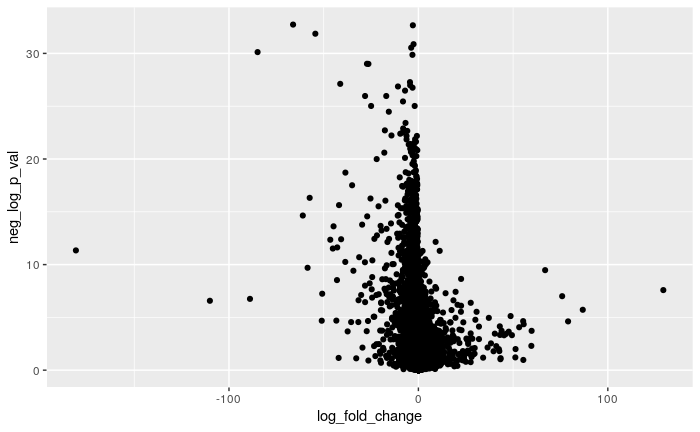

```r
stats_df %>%
  dplyr::filter(contrast == "astrocytoma_normal") %>%
ggplot2::ggplot(ggplot2::aes(x = log_fold_change,
                             y = neg_log_p_val)) +
  ggplot2::geom_point()
```

We can adjust the color points using `color`.

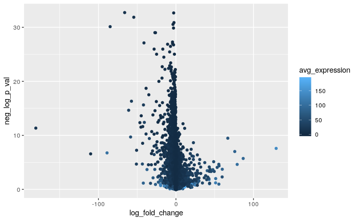

```r
stats_df %>%
  dplyr::filter(contrast == "astrocytoma_normal") %>%
ggplot2::ggplot(ggplot2::aes(x = log_fold_change,
                             y = neg_log_p_val,
                             color = avg_expression)) +
  ggplot2::geom_point()
```

We can also change the background and aesthetics by adding a `theme`.

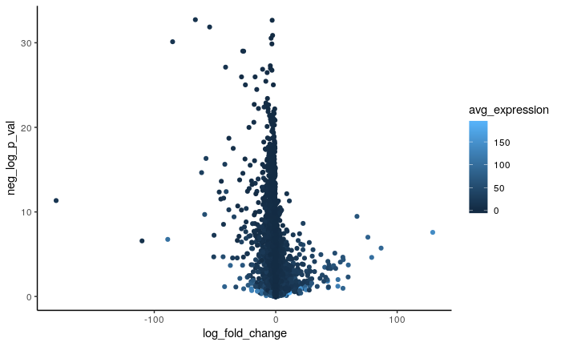

```r
stats_df %>%
  dplyr::filter(contrast == "astrocytoma_normal") %>%
ggplot2::ggplot(ggplot2::aes(x = log_fold_change,
                             y = neg_log_p_val,
                             color = avg_expression)) +
  ggplot2::geom_point() +
  ggplot2::theme_classic()
```

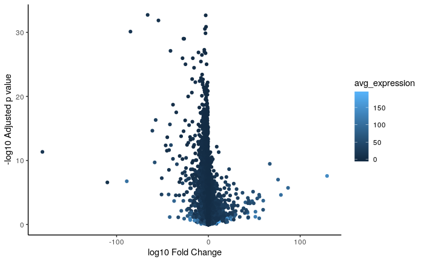

```r
stats_df %>%
  dplyr::filter(contrast == "astrocytoma_normal") %>%
ggplot2::ggplot(ggplot2::aes(x = log_fold_change,
                             y = neg_log_p_val,
                             color = avg_expression)) +
  ggplot2::geom_point() +
  ggplot2::theme_classic() +
  ggplot2::xlab("log10 Fold Change") +
  ggplot2::ylab("-log10 Adjusted p value")
```

```r
  ggplot2::ggtitle("Astrocytoma Tumor vs Normal Cerebellum")
```

```
$title
[1] "Astrocytoma Tumor vs Normal Cerebellum"

attr(,"class")
[1] "labels"
```

We can add all the contrasts to the plot by getting rid of the filter step and then add a `facet_wrap` to make each contrast its own plot.

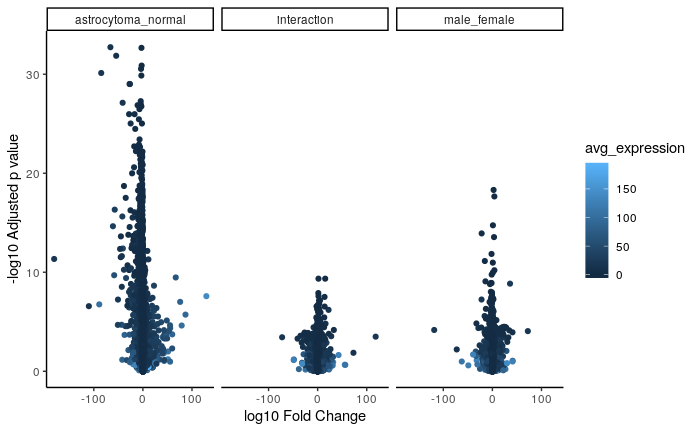

```r
stats_df %>%
ggplot2::ggplot(ggplot2::aes(x = log_fold_change,
                             y = neg_log_p_val,
                             color = avg_expression)) +
  ggplot2::geom_point() +
  ggplot2::theme_classic() +
  ggplot2::facet_wrap(~ contrast) +
  ggplot2::xlab("log10 Fold Change") +
  ggplot2::ylab("-log10 Adjusted p value")
```

We can store the plot as an object. Here we will call it `volcano_plot`.

```r
volcano_plot <- stats_df %>%
ggplot2::ggplot(ggplot2::aes(x = log_fold_change,
                             y = neg_log_p_val,
                             color = avg_expression)) +
  ggplot2::geom_point() +
  ggplot2::theme_classic() +
  ggplot2::facet_wrap(~ contrast) +
  ggplot2::xlab("log10 Fold Change") +
  ggplot2::ylab("-log10 Adjusted p value")
```

When we are happy with our plot, we can save the plot using `ggsave`.

```r
ggplot2::ggsave(plot = volcano_plot,
                filename = file.path(plots_dir, "volcano_plot.png"))
```

We can notice that some of these values with low p values seem very high for very log fold change.

## Apply some cutoffs.

Lets take a look at filtering genes by their average expression. Genes that are detected at too low of levels cannot be trusted to be accurately measured for differential expression.

Let’s get a summary of average expression of this dataset.

```r
summary(stats_df$avg_expression)
```

```
    Min.  1st Qu.   Median     Mean  3rd Qu.     Max.
 -0.7671   0.1754   0.7822   2.5023   2.4048 190.7080
```

Filter out expression values that are lower than the 1st Quartile and re-make the plot.

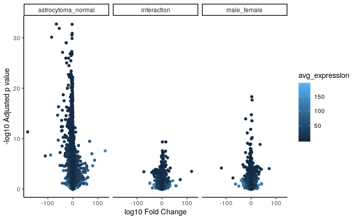

```r
stats_df %>%
  dplyr::filter(avg_expression > 0.1754) %>%
ggplot2::ggplot(ggplot2::aes(x = log_fold_change,
                             y = neg_log_p_val,
                             color = avg_expression)) +
  ggplot2::geom_point() +
  ggplot2::theme_classic() +
  ggplot2::facet_wrap(~ contrast) +
  ggplot2::xlab("log10 Fold Change") +
  ggplot2::ylab("-log10 Adjusted p value")
```

When we are done with the notebook, we want to print out the packages we’ve been using here so we can reproduce this if we need.

```r
# Print out the versions and packages we are using in this session
sessionInfo()
```

[output not shown]